# Chess Elo Prediction — Residual MLP (Static Features Only)

**Architecture:** A deeper residual MLP over static features (board + clock + AE embeddings), replacing the plain 3-layer MLP in v4. Skip connections between residual blocks prevent gradient vanishing and allow training much deeper than a plain stack of linear layers.

**Why it might work better:** The ablation results from earlier experiments showed that static features alone account for most of the predictive signal — clock behaviour, game length, capture density, and castling timing are strong Elo proxies. If the bottleneck is model capacity rather than feature type, a deeper residual network could extract more discriminative patterns from those same features without any sequence processing. A stronger static model might close the remaining gap without the compute cost of running an LSTM or Transformer on every batch.

**Honest tradeoff:** Residual networks shine when depth is genuinely useful — when the function being learned is compositional and benefits from many non-linear stages. For a tabular feature set of ~40 engineered features, it is not clear that depth helps much past 3-4 layers. The AE embeddings add 32 dimensions of compressed sequence information, which might give the residual network enough to work with — but if the signal is mostly captured in the first 2-3 layers already, adding more blocks will just add noise and regularisation cost. This might be the same as or slightly worse than v4. Worth measuring precisely.

**What HPO searches over:** number of residual blocks, hidden dimension, dropout.

**Baseline to beat:** v4 combined MAE ≈ 200 Elo.

## Config

```
Device : cpu  |  AMP : False  |  CPU threads : 14
Sequential=False  |  AE=True  |  DistTarget=True
MAX_GAMES=3,000,000  |  HIDDEN_DIM=256  |  N_BLOCKS=4
HPO_TRIALS=15  |  HPO_GAMES=50,000  |  HPO_EPOCHS=3
```

## Data Loading

```
Loaded 3,000,000 games in 339.8s
Removed 1,007,365 games by termination type
Kept 372,502 games after filters (removed 1,611,767)
Elo range — White: 771–2605,  Black: 762–2608
```

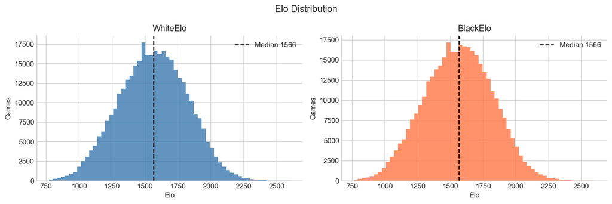

## Feature Extraction

```
Board features loaded from cache  (35 cols)
Clock features loaded from cache  (10 cols)
Full feature matrix: (372502, 69)
```

## Move Tokenisation

```
Dropped 6,099 games shorter than 12 plies
Vocabulary size : 9,682
Games ready     : 366,403
```

## Soft Distribution Targets

```
1600 Elo dist: peak at 1550,  recovered = 1600
```

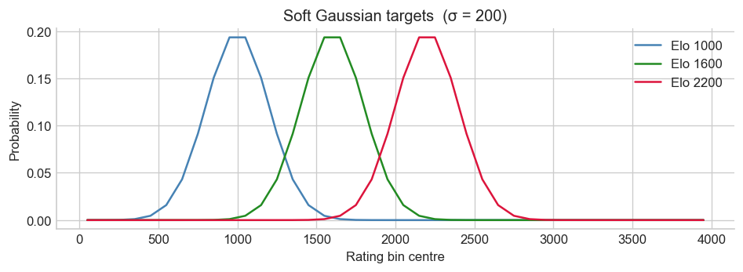

## Feature Selection, Train/Val/Test Split & Scaling

```
Static feature columns selected: 45
Split — train: 293,122  val: 36,640  test: 36,641
Scaling done (StandardScaler fit on train only)
```

## Sequence Autoencoder

Same AE as v4: BiLSTM encoder → 32-d bottleneck. Loaded from cache if available, otherwise trained. The AE embeddings give the residual MLP access to compressed sequence information as extra static features.

```
AE embeddings loaded from cache: (366403, 32)
AE embeddings ready — 32 dims per game
```

## Dataset & DataLoaders

```
Building datasets...
  Built in 89s   total static dim = 77
Batches per epoch: 2,291
```

## Model — Residual MLP

Each residual block: `LayerNorm → Linear → GELU → Dropout → Linear → LayerNorm` with a skip connection. Pre-norm (LayerNorm before the non-linearity) is more stable than post-norm when stacking many blocks.

An input projection lifts the feature vector to `hidden_dim`, then N residual blocks process it, and two output heads (White/Black) produce 40-bin softmax distributions.

```
Model built — 1,096,784 trainable parameters  |  hidden_dim=256  n_blocks=4
```

## Hyperparameter Optimisation (Optuna)

15 trials on a 50k-game subset, 3 training epochs each. Searches:

- `n_blocks`: residual depth {2, 4, 6, 8}
- `hidden_dim`: feature width {128, 256, 512}
- `dropout`: regularisation strength {0.1 … 0.4}

```
Best trial  val_loss=0.7473
Best params: {'n_blocks': 2, 'hidden_dim': 256, 'dropout': 0.11103653555313633}

Full training will use: n_blocks=2  hidden_dim=256  dropout=0.111
```

## Training

[output not shown]

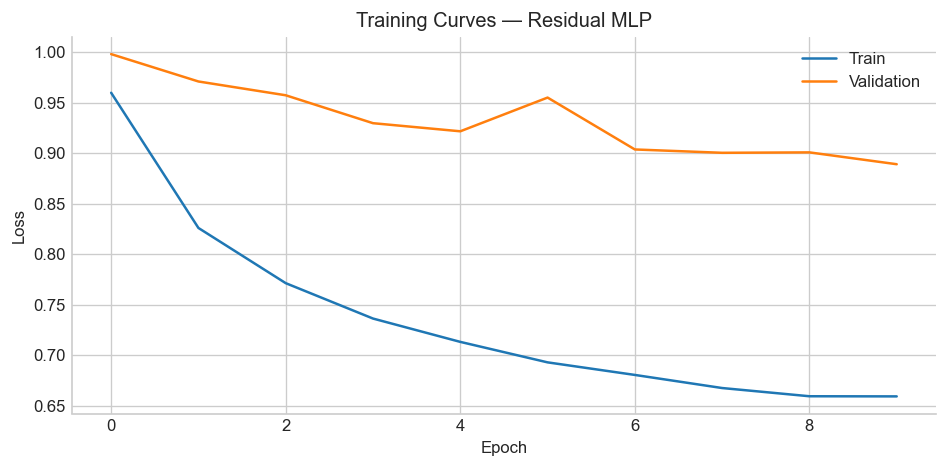

## Evaluation

```
Loaded checkpoint: checkpoints\residual_3e+06.pth
MAE    — White: 186.1  Black: 184.6  Combined: 185.3
Median — White: 153.2  Black: 152.7
Within 100 Elo: 34.3%
Within 200 Elo: 61.9%
Within 300 Elo: 80.6%
```

```
==================================================
  Architecture Comparison
==================================================
  v4 (BiLSTM + AE)       combined MAE ≈ 200.0
  Residual MLP (this)    combined MAE  = 185.3
  Δ = -14.7 Elo  (better than baseline)
==================================================
```

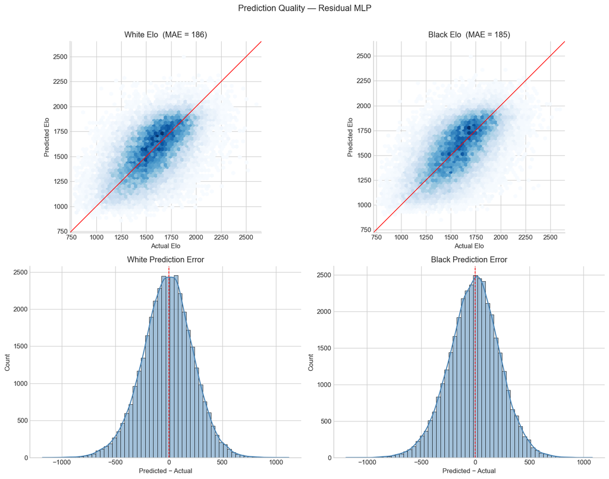

```
MAE by Elo bracket:
------------------------------------------
           (0, 1000]  MAE =   278  n = 874
        (1000, 1200]  MAE =   199  n = 5,166
        (1200, 1400]  MAE =   183  n = 13,476
        (1400, 1600]  MAE =   176  n = 20,505
        (1600, 1800]  MAE =   169  n = 19,467
        (1800, 2000]  MAE =   189  n = 10,752
        (2000, 2200]  MAE =   276  n = 2,639
        (2200, 2500]  MAE =   423  n = 396
        (2500, 4000]  MAE =   733  n = 7
```

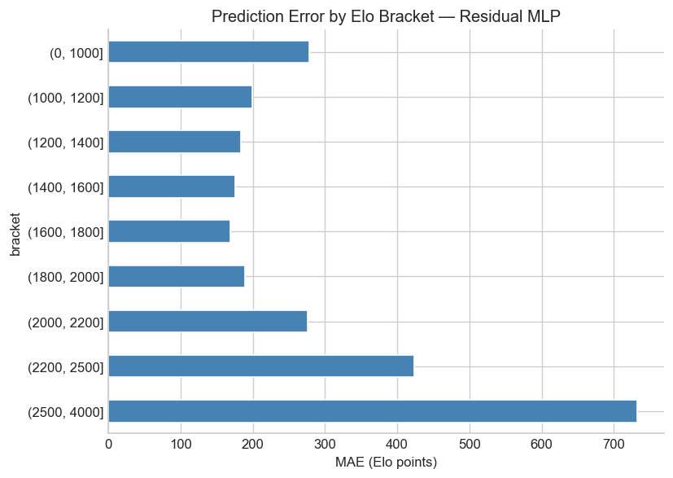

## Predicted Rating Distributions

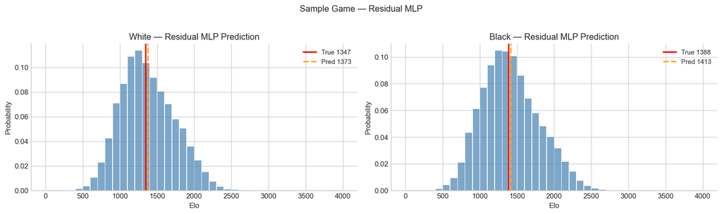

## Latent Space — t-SNE & PCA

```
Running t-SNE on 3000 vectors...
```

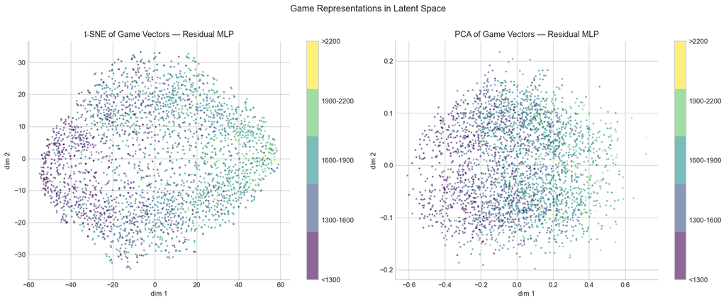

## Feature Group Importance

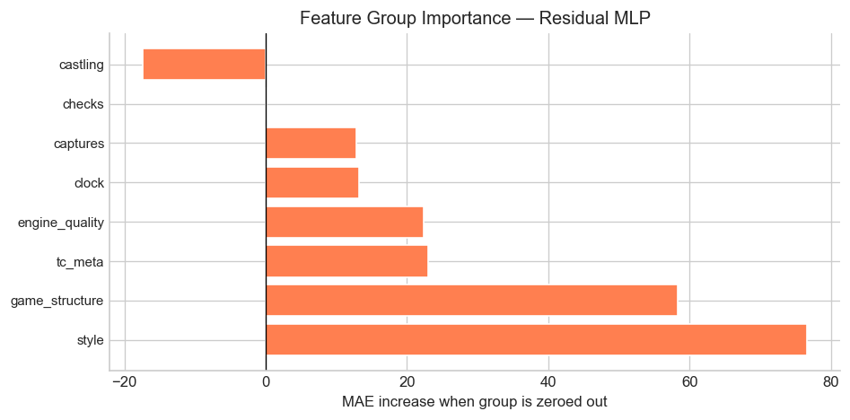

```
  style               Δ = +76.6
  game_structure      Δ = +58.3
  tc_meta             Δ = +23.0
  engine_quality      Δ = +22.3
  clock               Δ = +13.2
  captures            Δ = +12.8
  checks              Δ = +0.1
  castling            Δ = -17.4
```

## Anomaly Detection

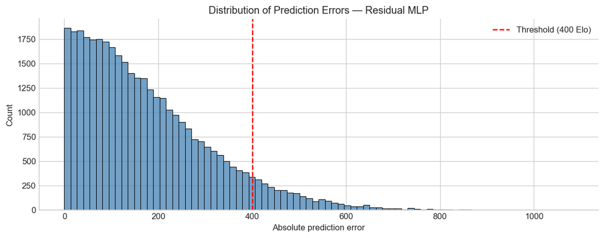

```
Flagged 2825 games with error > 400 Elo  (7.7%)
```

## Single-Game Inference

Paste any PGN below and run the cell. Works with Lichess and chess.com exports.

```
=============================================
  White Elo   predicted:  1848   actual: 1546
  Black Elo   predicted:  1763   actual: 1534
=============================================
```

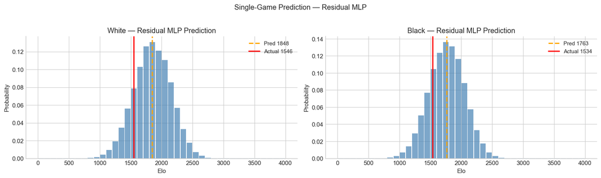